# Taper functios literature

# Literature search

[figure not shown]

```r
plot(cars)
```

## ArticleID:001

Title: Comparison of taper functions applied to eucalypts of varying genetics in Brazil: Application and evaluation of the penalized mixed spline approach Source: (2018) Canadian Journal of Forest Research, 48 (5), pp. 568-580, DOI: 10.1139/cjfr-2017-0366 URL: https://www.scopus.com/inward/record.uri?eid=2-s2.0-85046101611&doi=10.1139%2fcjfr-2017-0366&partnerID=40&md5=6ca12aa51842a6a8d86630c3e88d440f

Function Species: Eucalypts Code

## ArticleID:002

Student: Angelo Manca PubblicationYear:2016 Authors: Andrew J. Warner, Monton Jamroenprucksa, Ladawan Puangchit,

Title: Development and evaluation of teak (Tectona grandis L.f.) taper equations in northern Thailand, Source: Agriculture and Natural Resources, Volume 50, Issue 5, Pages 362-367, ISSN 2452-316X, URL: https://doi.org/10.1016/j.anres.2016.04.005. (http://www.sciencedirect.com/science/article/pii/S2452316X16302459)

Function Species: Tectona grandis L.f.

Code :

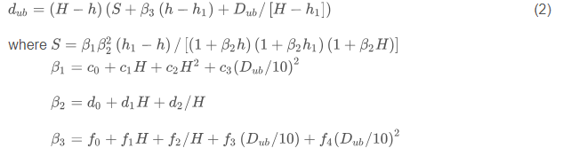

Title:Development of a Compatible Taper Function and Stand-Level Merchantable Volume Model for Chinese Fir Plantations Source:Rongling Wu, Editor URL:https://www.ncbi.nlm.nih.gov/pmc/articles/PMC4723312/

Function Species:Cunninghamia lanceolata [Lamb.] Hook

Code:

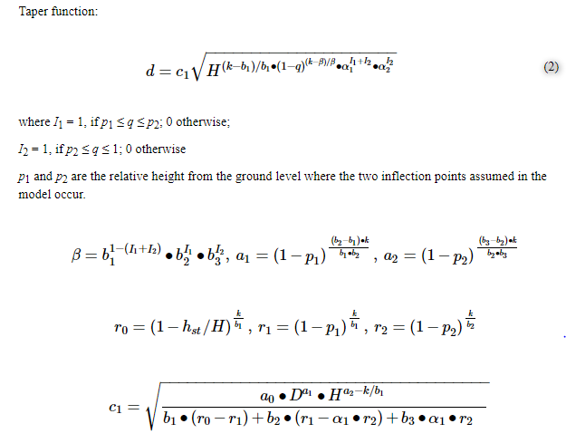

## ArticleID:004

Student: Maria Chiara Ruggiu PubblicationYear: 2017 Authors:José Javier Corral-Rivas, Daniel Jose Vega-Nieva, Roque Rodríguez-Soalleiro, Carlos Antonio López-Sánchez, Christian Wehenkel, Benedicto Vargas-Larreta, Juan Gabriel Álvarez-González and Ana Daría Ruiz-González.

Title: “Compatible System for Predicting Total and Merchantable Stem Volume over and under Bark, Branch Volume and Whole-Tree Volume of Pine Species”"

Source:Forests 2017, Volume 8, Issue 11, 417, MDPI AG URL:https://doi.org/10.3390/f8110417

Function

Species: Pinus cooperi, Pinus durangensis

Code:

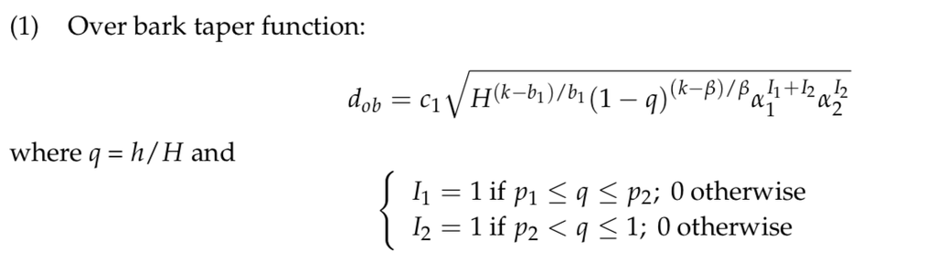

## ArticleID: 005

Student: Matteo Piccolo PubblicationYear: 2016 Authors: Yuan Sun, Xinlian Liang, Ziyu Liang, Clive Welham and Weizheng Li

Title: Deriving Merchantable Volume in Poplar through a Localized Tapering Function from Non-Destructive Terrestrial Laser Scanning Source: Forests 2016

URL: http://www.mdpi.com/1999-4907/7/4/87/htm

Function Species: Populus × canadensis Moench cv. Code

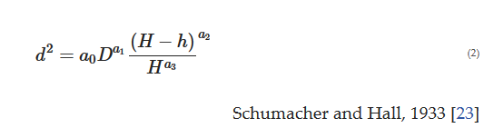

## ArticleID: 006

Student: PubblicationYear: 2017 Authors: Ana Paula Marques Martins, Aline Bernarda Debastiani, Allan Libanio Pelissari, Sebastião do Amaral Machado, Carlos Roberto Sanquetta

Function Species: Araucaria angustifolia Code

## ArticleID: 007

Student: PubblicationYear: 2006 Authors: Lana Mirian Santos da Silva, Luiz Carlos Estraviz Rodriguez, José Vicente Caixeta Filho; Simone Carolina Bauch

Title: Fitting a taper function to minimize the sum of absolute deviations Source: Scientia Agricola Url: http://www.scielo.br/scielo.php?script=sci_arttext&pid=S0103-90162006000500007

Function Species: Eucalyptus Code

## ArticleID: 008

Student: PubblicationYear: 2016 Authors: Emanuel Arnoni Costa, César Augusto Guimarães Finger, Paulo Renato Schneider, André Felipe Hess

Title: Taper function and timber assortments for Araucaria angustifolia Source: Ciência Florestal Url: http://www.redalyc.org/articulo.oa?id=53446151016

Function Species: Araucaria angustifolia Code

## ArticleID: 009

Student: PubblicationYear: 2008 Authors: Carlos Alberto Martinelli de Souza, Tatiane Chassot, César Augusto Guimarães Finger, Paulo Renato Schneider, Frederico Dimas Fleig

Title: Taper function for assortment of Pinus taeda L. stem Source: Ciência Rural Url: http://www.scielo.br/scielo.php?script=sci_arttext&pid=S0103-84782008000900014

Function Species: Pinus taeda L Code

## ArticleID: 010

Student: PubblicationYear: 2015 Authors: Manuel Arias-Rodil, Fernando Castedo-Dorado, Asunción Cámara-Obregón, Ulises Diéguez-Aranda

Title: Fitting and Calibrating a Multilevel Mixed-Effects Stem Taper Model for Maritime Pine in NW Spain Source: PLOS One Url: http://europepmc.org/backend/ptpmcrender.fcgi?accid=PMC4668033&blobtype=pdf

Function Species: Pinus pinaster Ait. Code

## ArticleID: 011

Student: PubblicationYear: 2015 Authors: Francisco Rodríguez1, Iñigo Lizarralde1 and Felipe Bravo

Title: Comparison of stem taper equations for eight major tree species in the Spanish Plateau Source: Instituto Nacional de Investigación y Tecnología Agraria y Alimentaria (INIA) Url: http://revistas.inia.es/index.php/fs/article/download/6229/2595

Function Species: Various Code

## ArticleID: 012

Student: PubblicationYear: 2013 Authors: J. Návar, F. de Jesús Rodríguez-Flores, P.A. Domínguez-Calleros

Title: Taper functions and merchantable timber for temperate forests of northern Mexico Source: ANNALS OF FOREST RESEARCH www.e-afr.org Url: http://www.editurasilvica.ro/afr/56/1/navar.pdf

Function Species: P.pseudostrobus, P. hartwegii, P. cooperi, P. ayacahuite, Q. spp, P. durangensis, P. leiophylla, P. teocote, P. arizonica, Quercus spp Code

## ArticleID: 013

Student: PubblicationYear: 2017 Authors: Ramazan Özçelik, Osman Dirican

Title: Individual taper models for natural cedar and Taurus fir mixed stands of Bucak Region, Turkey Source: Journal of the Faculty of Forestry Istanbul University Url: http://dergipark.gov.tr/download/article-file/330518

Function Species: Cedrus libani A. Rich., Abies cilicica Carr. Code

## ArticleID: 014

Student: PubblicationYear: 2005 Authors: Sebastião do Amaral Machado, Edilson Urbano, Marcio Barbosa da Conceição

Title: Comparação de Métodos de Estimativa de Volume para Pinus oocarpa em Diferentes Idades e Diferentes Regimes de Desbastes Source: Url: https://pfb.cnpf.embrapa.br/pfb/index.php/pfb/article/view/242/193

Function Species: Pinus oocarpa Code